# ST 518 Final Re-do

Zoe Aiello

2023-02-24

## Introduction

**Background** The Forest Cover Type data set is from Colorado State University and includes both categorical and quantitative variables that describe 13 cartographic features for 581,012 30x30 meter cells in four wilderness areas of the Roosevelt National Forest in Colorado. The forest cover type was determined by the US Forest Service Region 2 Resource Information System, a geo-spatial database for the Rocky Mountain Region of the US. The explanatory variables were pulled from data obtained by the US Geological Survey and the US Forest Service. I was unable to find the associated publication for the USGS and USFS data. Therefore, I am unsure of the exact methods used to sample the 30x30 meter plots but I will assume that the data collectors utilized a random sampling scheme. Since the data set was so large, I needed to take a random sample from within the larger sample to account for the perils of a big ‘n’. The perils of big ‘n’ describes the statistical implications of using a large data set where even minute associations are deemed statistically significant even when they are not practically important. In this paper, we will explore the development of a predictive model for forest cover type using cartographic features.

We begin with an exploration of the data. The variables are described in Table 1.

**Data Exploration**

Table 1. Variable Summary

| Variable | Description |
| --- | --- |
| Elevation | Quantitative (in meters) |
| Aspect | Quantitative (in degrees azimuth) |
| Slope | Quantitative (in degrees) |
| Horizontal Distance to Hydrology | Quantitative (in meters) |
| Vertical Distance to Hydrology | Quantitative (in meters) |
| Horizontal Distance to Roadways | Quantitative (in meters) |
| Hillshade (9am) | Quantitative (in hillshade index) |
| Hillshade (12pm) | Quantitative (in hillshade index) |
| Hillshade (3pm) | Quantitative (in hillshade index) |
| Horizontal Distance to Fire Points | Quantitative (in meters) |
| Wilderness Area | Four binary variables (1 indicates presence, 0 indicates absence) |
| Soil Type | Fourty binary variables (1 indicates presence, 0 indicates absence) |
| Cover Type | Nominal Cateogrical (7 classes, response variable) |

Cover Type is described as a nominal categorical variable since its categories do not have a natural order (Table 1). The categories of cover type are are described as follows:

1 - Spruce/Fir

2 - Lodgepole Pine

3 - Ponderosa Pine

4 - Cottonwood/Willow

5 - Aspen

6 - Douglas-fir

7 - Krummholz

As expected, the distribution of Cover Type is non-normal since it is a count variable (Figure 1). Most cases are have a Spruce/Fir (1) or Lodgepole Pine (2) cover type while the Cottonwood/Willow cover type (4) occurred in the lowest frequency.

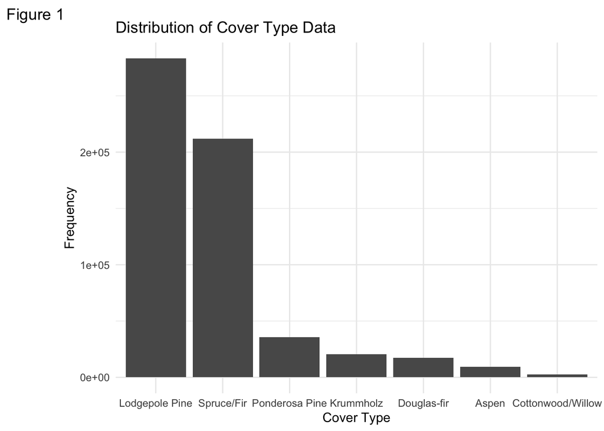

Out of all the relationships between Cover Type and the explanatory variables, the relationship between Cover Type and elevation appears to be the most interesting. The Krummholz cover type appears most frequently at the highest elevations, the Spruce/Fir cover type appears at a wide range of elevations from about 2500 meters to over 3500m. The Douglas-fir cover type appears at the lower elevations between about 2000m to 3000m.

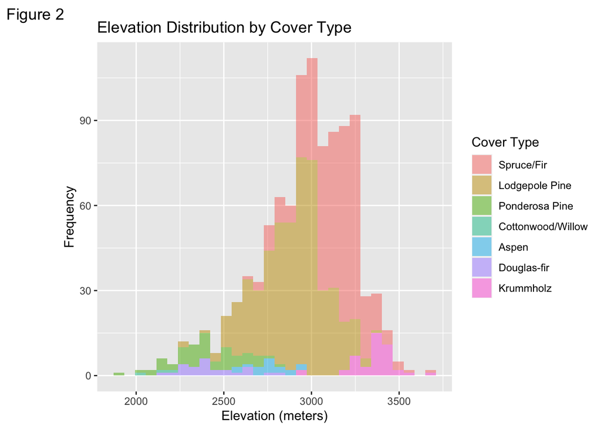

It seems that elevation and soil type are correlated: rubbly soil types occur at lower elevations whereas stony and extremely stony soil types occur at higher elevations and complex soil types seem to occur throughout the range of elevations (Figure 3). We can also see the distribution of the different wilderness areas. Coman wild area is fairly evenly distributed at all elevations whereas cache is at the lowest elevation and neota is at the highest. Rowah appears pretty much in the middle (Figure 3).

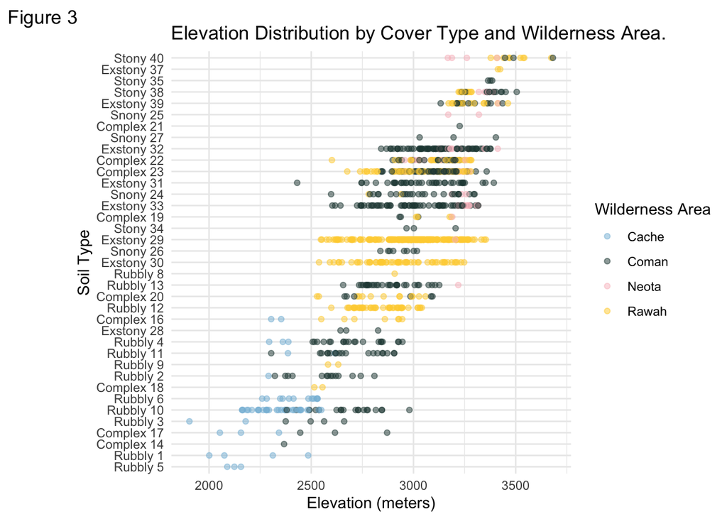

## Methods

To answer our question of interest we will use a multinomial logistic regression model.

**Multinomial Logistic Regression Model**

The multinomial logistic regression is an extension of the binomial logistic regression and models nominal categorical response variables using maximum likelihood estimation. The multinomial logit model was developed by McFadden in the 1970’s originally under the name “Conditional Logit Model” (McFadden, 1973). In a binary logit model, we would model the log odds of Y = 1 as a linear function of the X’s like so:

$$log(\frac{P(Y = 1|x)}{P(Y = 0 | x)}) =
a + bx$$
Here, b measures the change in the log odds of Y = 1 when X changes by one unit.

The multinomial logit extends this binary logit with K-1 equations where K is the number of cateogries in the response variable and we model the relationship between Y and X with K-1 equations like so:

$$log(\frac{P(Y = 1|x)}{P(Y = K | x)}) =
a_1 + b_1x$$
…

$$log(\frac{P(Y = K-1|x)}{P(Y = K | x)})
= a_{K-1} + b_{K-1}x$$
where $b_1$ measures the change in the log odds of Y=1 relative to Y=K when X changes by one unit. In this circumstance, Y=K is our reference level.

In the forest cover type data, we have K = 7 categories in our response variable and we will arbitrarily use cover type 1 as our reference level.

## Results

**Fit Model** Soil type and Wild area don’t have every combination with the response variable so the model cannot converge with the missing combinations. For these reason, I’ve excluded these two variables from the model.

Let’s do a test for significance of our model coefficients:

$H_0: \beta_i = 0$ and $H_A: \beta_i \neq 0$ where $\beta_i$ is the coefficient for the $i^{th}$ variable.

```
##   (Intercept)    elevation    aspect vert_dist_hydro horz_dist_road
## 2           0 0.000000e+00 0.7090624      0.67277846    0.415259106
## 3           0 0.000000e+00 0.3764811      0.04917866    0.624135377
## 4           0 4.853553e-09 0.5151726      0.75906351    0.069443710
## 5           0 8.812062e-12 0.3502062      0.41671569    0.008626103
## 6           0 0.000000e+00 0.8865834      0.92114525    0.608434794
## 7           0 1.687761e-12 0.3221137      0.84476878    0.574068383
##      shade_9am    shade_3pm   shade_noon horz_dist_hydro        slope
## 2 2.199011e-05 1.172753e-05 6.442094e-07    0.0006486717 5.958507e-01
## 3 1.136920e-05 5.968288e-04 6.363107e-01    0.2062212375 2.039564e-09
## 4 1.922835e-02 7.271271e-02 6.608638e-01    0.7298791712 8.679993e-03
## 5 5.460139e-04 3.754322e-02 6.997708e-01    0.7893044989 8.946003e-08
## 6 0.000000e+00 0.000000e+00 7.449596e-13    0.1582822816 0.000000e+00
## 7 1.634414e-01 2.197091e-01 3.677742e-01    0.7299533738 1.307493e-01
```

According to the t-test, aspect is not significant at the 0.05 level and should be dropped from our model. Additionally, drop horz_dist_hydro (covertype = 2), horz_dist_road (covertype = 5), and vert_dist_hydro (covertype = 3) are only significant for one cover type level so I will keep this in mind as I refit the model without aspect and assess the variables for multicolinearity.

Use cor() to find any multi-colinear variables and remove variables that have a pearson correlation coefficient above abs(0.5).

```
##                   elevation vert_dist_hydro horz_dist_road horz_dist_hydro
## elevation        1.00000000     0.079579461    0.375551562     0.289494632
## vert_dist_hydro  0.07957946     1.000000000   -0.002091029     0.637532883
## horz_dist_road   0.37555156    -0.002091029    1.000000000     0.130205276
## horz_dist_hydro  0.28949463     0.637532883    0.130205276     1.000000000
## shade_9am        0.13895052    -0.163003088    0.064020401     0.004326869
## shade_3pm        0.02716591     0.034154927    0.056701308     0.018119941
## shade_noon       0.17770062    -0.096172429    0.144216572     0.030283131
## slope           -0.25757965     0.242373468   -0.192032213    -0.034338015
##                    shade_9am   shade_3pm  shade_noon       slope
## elevation        0.138950516  0.02716591  0.17770062 -0.25757965
## vert_dist_hydro -0.163003088  0.03415493 -0.09617243  0.24237347
## horz_dist_road   0.064020401  0.05670131  0.14421657 -0.19203221
## horz_dist_hydro  0.004326869  0.01811994  0.03028313 -0.03433801
## shade_9am        1.000000000 -0.76823383 -0.02170801 -0.29480643
## shade_3pm       -0.768233831  1.00000000  0.63528167 -0.21674510
## shade_noon      -0.021708009  0.63528167  1.00000000 -0.51616197
## slope           -0.294806434 -0.21674510 -0.51616197  1.00000000
```

These variables had a pearson correlation coefficient above abs(0.5):

- vert_dist_hydro and horz_dist_hydro
- shade 9am and shade 3pm
- shade 3pm shade noon
- shade noon and slope

I must remove shade noon, shade 3pm, and vert_dist_hydro due to multicolinearity, I chose shade noon and shade 3pm because they were both multicolinear with two variables. I chose to remove vert_dist_hydro rather than horz_dist_hydro because its one significant coefficient had a p-value that was very close to 0.05 (p=0.049).

A new model accounting for these changes was fit.

```
## Call:
## multinom(formula = covertype ~ elevation + horz_dist_road + shade_9am +
##     horz_dist_hydro + slope, data = samp2, model = TRUE)
##
## Coefficients:
##   (Intercept)    elevation horz_dist_road    shade_9am horz_dist_hydro
## 2    27.22749 -0.009213914   5.486684e-05  0.001248488    0.0018831201
## 3    62.17332 -0.024894770   3.235184e-04  0.012344752    0.0053650874
## 4    82.73742 -0.036764463   2.592626e-03  0.027343686   -0.0041412400
## 5    23.21475 -0.010057342  -8.882352e-04  0.017654346   -0.0005644171
## 6    64.19671 -0.024454094   5.001054e-04 -0.001012596    0.0037311366
## 7   -42.66609  0.011626458   6.447330e-05  0.010998376   -0.0003819967
##          slope
## 2 -0.007290830
## 3  0.051462070
## 4  0.019438027
## 5  0.078998290
## 6 -0.007500579
## 7  0.025422698
##
## Std. Errors:
##    (Intercept)    elevation horz_dist_road   shade_9am horz_dist_hydro
## 2 8.623326e-05 0.0002712891   5.394454e-05 0.003537992    0.0004017146
## 3 1.091844e-04 0.0008921583   2.735954e-04 0.008724171    0.0014880360
## 4 7.160241e-05 0.0023591263   6.934479e-04 0.021348767    0.0105616257
## 5 7.858374e-05 0.0008470698   3.488134e-04 0.009627061    0.0018873392
## 6 2.105683e-04 0.0010380475   3.232954e-04 0.010127970    0.0019187544
## 7 7.240793e-06 0.0006188126   1.398430e-04 0.008486303    0.0007806418
##        slope
## 2 0.01248868
## 3 0.03327960
## 4 0.07402170
## 5 0.03467715
## 6 0.03876672
## 7 0.02579625
##
## Residual Deviance: 1438.194
## AIC: 1510.194
```

Now we can write our equations according to the models predicted coefficients:

$$Log[\frac{P(Covertype = 2)}{P(Covertype
= 1)}] = 27.22749 - 0.009213914*Elevation +..$$
$$..5.486684e^{-05}*HorzDistRoad +
0.001248488*Shade9am + 0.0018831201*HorzDistHydro -
0.007290830*Slope$$

$$Log[\frac{P(Covertype = 3)}{P(Covertype
= 1)}] = 62.17332 - 0.024894770*Elevation +..$$
$$..3.235184e^{-04}*HorzDistRoad +
0.012344752*Shade9am + 0.0053650874*HorzDistHydro +
0.051462070*Slope$$

$$Log[\frac{P(Covertype = 4)}{P(Covertype
= 1)}] = 82.73742 - 0.036764463*Elevation +..$$
$$..2.592626e^{-03}*HorzDistRoad +
0.027343686*Shade9am - 0.0041412400*HorzDistHydro +
0.019438027*Slope$$

$$Log[\frac{P(Covertype = 5)}{P(Covertype
= 1)}] = 23.21475 - 0.010057342*Elevation -..$$
$$..8.882352e^{-04}*HorzDistRoad +
0.017654346*Shade9am - 0.0005644171*HorzDistHydro
+ 0.078998290*Slope$$

$$Log[\frac{P(Covertype = 6)}{P(Covertype
= 1)}] = 64.19671 - 0.024454094*Elevation +..$$
$$..5.001054e^{-04}*HorzDistRoad -
0.001012596*Shade9am + 0.0037311366*HorzDistHydro -
0.007500579*Slope$$

$$Log[\frac{P(Covertype = 7)}{P(Covertype
= 1)}] = -42.66609 + 0.011626458*Elevation +..$$
$$..6.447330e^{-05}*HorzDistRoad +
0.010998376*Shade9am - 0.0003819967*HorzDistHydro +
0.025422698*Slope$$

**Model Assessment**

Table 2: Confustion Matrix

| 1 | 2 | 3 | 4 | 5 | 6 | 7 |
| --- | --- | --- | --- | --- | --- | --- |
| 1312 | 580 | 0 | 0 | 0 | 0 | 139 |
| 476 | 1862 | 100 | 0 | 92 | 40 | 0 |
| 0 | 20 | 204 | 27 | 0 | 89 | 0 |
| 0 | 0 | 2 | 8 | 0 | 0 | 0 |
| 0 | 0 | 0 | 0 | 0 | 0 | 0 |
| 0 | 0 | 2 | 1 | 0 | 0 | 0 |
| 19 | 0 | 0 | 0 | 0 | 0 | 27 |

Table 3

|  | Misclassification.Rate | McFadden.s.R.2 |
| --- | --- | --- |
| Metric | 0.3174 | 0.4029076 |

## Discussion & Conclusion

The purpose of this analysis was to develop a predictive model for cover type based on the cartographic information of 30x30 meter plots. The model resulted in a McFadden’s $R^2$ value of 0.4029 which suggests that the fit is OK (Table 3). According to McFadden (1974), McFadden $R^2$ values between 0.2 and 0.4 indicate an excellent model fit (https://stats.stackexchange.com/questions/82105/mcfaddens-pseudo-r2-interpretation). However, when evaluated the model on the testing data the misclassification rate was about 31.7% (Table 3). The model’s performance may be lacking because of the smaller sample size that I used. I initially tried to take an equal number of observations from each cover type to ensure that there was enough data in each cover type for my model to train on, but this changed the shape of the distribution which caused my model to exhibit complete separation (see appendix for justification of Multinomial Logit Assumptions). In the future, it might be useful to take a random sample based on percentage of cover type so that I can ensure that each cover type is adequately represented without falling into the trap of a massive sample size.

## Appendix

### Multinomial Logistic Regression Assumption Justifications

Multinomial logistic regression is an extension of the binomial logistic regression but it models nominal categorical response variables and does not assume normality, linearity or homoscedasity. It uses maximum likelihood estimation and has a few key assumptions:

**1. Sample size**

All the levels of Cover type have over 10 observations so the sample size assumption is met.

```
##      1      2      3      4      5      6      7
## 211840 283301  35754   2747   9493  17367  20510
```

**2. Non-Perfect Separation**

Complete separation and quasi-complete separation prevent the convergence of maximum likelihood estimation for the coefficients. Complete separation occurs when a linear combination of the predictors yield a perfect prediction of the response variable. Quasi-complete separation means the predictors yield a perfect prediction of the response variable for most values of the predictors but not all.

We can test for complete or quasi-complete separation by examining the frequency of each alternative category in the data. If any alternative category has a frequency of 0 or 1, then that suggests that there is perfect separation, which violates the assumption of the model. In this case, the levels of the response variable (Cover type) are represented by the numbers 1 through 7. The frequencies of alternatives indicate the probability that each level of the response variable will occur given the predictor variables. In this case, the frequencies of the cover-type categories show that the assumption of non-perfect separation is satisfied.

```
##           1           2           3           4           5           6
## 0.386247774 0.467713444 0.057886623 0.003174708 0.016639333 0.024883390
##           7
## 0.043454727
```

**3. Multicolinearity.**

Multicolinearity occurs when explanatory variables in a model are correlated. This means that the correlated variables contain the same information about the response variable and including both in the model would be redundant. Multicolinearity can impact the model’s estimated coefficients and increase uncertainty which can further impact hypothesis tests. We would commonly use the variance inflation factor (VIF) to assess the multicolinearity in our model. However, the vif() function in R is inadequate for calculating the variance inflation factor for a multinomial logit model so we will use the cor() function which calculates the pearson correlation coefficient for each of the proposed variables. We will remove any variables that have a pearson correlation coefficient above abs(0.5)

```
##                   elevation      aspect vert_dist_hydro horz_dist_road
## elevation        1.00000000 -0.02752071     0.079579461    0.375551562
## aspect          -0.02752071  1.00000000     0.068998864   -0.014525212
## vert_dist_hydro  0.07957946  0.06899886     1.000000000   -0.002091029
## horz_dist_road   0.37555156 -0.01452521    -0.002091029    1.000000000
## shade_9am        0.13895052 -0.57746675    -0.163003088    0.064020401
## shade_3pm        0.02716591  0.64577214     0.034154927    0.056701308
## shade_noon       0.17770062  0.35503755    -0.096172429    0.144216572
## horz_dist_hydro  0.28949463 -0.01503127     0.637532883    0.130205276
## slope           -0.25757965  0.05895727     0.242373468   -0.192032213
##                    shade_9am   shade_3pm  shade_noon horz_dist_hydro
## elevation        0.138950516  0.02716591  0.17770062     0.289494632
## aspect          -0.577466749  0.64577214  0.35503755    -0.015031272
## vert_dist_hydro -0.163003088  0.03415493 -0.09617243     0.637532883
## horz_dist_road   0.064020401  0.05670131  0.14421657     0.130205276
## shade_9am        1.000000000 -0.76823383 -0.02170801     0.004326869
## shade_3pm       -0.768233831  1.00000000  0.63528167     0.018119941
## shade_noon      -0.021708009  0.63528167  1.00000000     0.030283131
## horz_dist_hydro  0.004326869  0.01811994  0.03028313     1.000000000
## slope           -0.294806434 -0.21674510 -0.51616197    -0.034338015
##                       slope
## elevation       -0.25757965
## aspect           0.05895727
## vert_dist_hydro  0.24237347
## horz_dist_road  -0.19203221
## shade_9am       -0.29480643
## shade_3pm       -0.21674510
## shade_noon      -0.51616197
## horz_dist_hydro -0.03433801
## slope            1.00000000
```

**4. Independence**

*Independence of Irrelevant Alternatives*

The Multinomial Regression Model assumes the Independence of Irrelevant Alternatives (IIA) which states that the model’s choice between two outcomes (e.g. Covertype 1 or Covertype 2) is not impacted by the alternative options (McFadden, 1984). The IIA assumption arises out of the logit model’s assumption of independent, identically distributed error terms for each choice. It is assumed that the attributes affecting cover type choice that are not included explicitly in the model will be captured by the error terms. A problem arises when some of the error terms share the same attributes, violating this assumption of independence. A famous example of this is the red bus-blue bus problem which describes a situation in which we use a multinomial logistic regression to model the share of riders for different transportation options. Initially, we model the share of riders for cars and red buses and determine that each has a ridership of 50%. However, when we add a blue-colored bus into the equation, the model will predict that the ridership for each transportation option will be 33%. Intuitively, this doesn’t make sense; we would assume that most of the blue-bus riders would originate from red-bus riders since they share many practical similarities (comfort, convenience, cost, etc.) and the rider share should be closer to 50% for cars, 25% for blue buses, and 25% for red buses. Mathematically, this is because many of the same confounding factors that impact a rider’s decision to take a bus rather than a car are included in the error terms for both the red bus and the blue bus, making those errors correlated and violating the IIA. In practice, the IIA assumption is difficult to justify and often impractical and unrealistic. However, the IIA can be tested using the Hausman-McFadden Test which compares the full model to a reduced model without certain alternatives to determine if those selected alternatives are irrelevant or not. We will use this test but take the results with a grain of salt since tests for IIA are often scrutinized in the literature.

The Cache wildtype area is more unique than the other wildtype areas according to the dataset information. This wildtype area is composed of primarily covertypes 3, 6, and 4. I will try removing these covertypes for the alternative model to see if they have an effect on the IIA.

Since we’re suspicious of the Hausman-McFadden test, let’s compare the coefficients of the two models, if their coefficients aren’t significantly different, the IAA assumption holds.

[output not shown]

```
## [1] 1510.194
```

```
## [1] 2420.662
```

Since tests for IIA are often scrutinized in the literature and the coefficients from the full and reduced models seem fairly similar. I will assume that the IIA is fulfilled in the full model and use all of the cover type categories for my model.

Worth noting, however, is the nested logit model. McFadden developed several solutions to the IIA assumption, one of which is the nested logit model which assumes that the decision-making process occurs in stages. So, in the context of the red-bus-blue-bus problem, instead of choosing between a car, red-bus, and blue-bus, we first choose between a car and a bus and then choose between a red-bus or blue-bus. In the nested logit, the IIA assumption is only present within each nest and not between each nest.

One possible way to nest the seven forest cover types is to group them by forest type. Spruce/Fir, Lodgepole Pine, Ponderosa Pine, Douglas-fir, and Krummholz are all coniferous forests. Cottonwood/Willow and Aspen are both deciduous forests. This nesting structure is described in the following figure:

[interactive chart not shown]

This is a possible solution to the IIA assumption that could be used in a future project but is out of the scope of this report.

*Geo-spatial dependence* Another possible violation of independence I want to mention is geo-spatial dependence between the 30x30 meter plots. It would make sense that plots closer to each other in space would have similar values. I did try to develop a distance matrix based on the elevation, slope, and aspect for use in spatial filtering but ended up scrapping it as I was way in over my head. This could be a great future project especially if the associated publication could be found with the coordinate information of the plots.

### Code

```r
knitr::opts_chunk$set(echo = TRUE)
library(kableExtra)
library(DiagrammeR)
library(ggplot2)
library(tidyverse)
library(forcats)
library(mlogit)
library(car)
library(nnet)
library(Metrics)
library(aod)
library(sjPlot)
library(scales)
library(dplyr)
# install.packages("DescTools")
library(DescTools)
### Import Data ###
# import data
covdata <- read.csv('covtype.data', header=FALSE)

# column names
colnames(covdata) <- c('elevation',
                       'aspect',
                       'slope',
                       'horz_dist_hydro',
                       'vert_dist_hydro',
                       'horz_dist_road',
                       'shade_9am',
                       'shade_noon',
                       'shade_3pm',
                       'horz_dist_fire',
                       'rawah_wild_area',
                       'neota_wild_area',
                       'coman_wild_area',
                       'cache_wild_area',
                       'soil_rubbly_1',
                       'soil_rubbly_2',
                       'soil_rubbly_3',
                       'soil_rubbly_4',
                       'soil_rubbly_5',
                       'soil_rubbly_6',
                       'soil_rubbly_7',
                       'soil_rubbly_8',
                       'soil_rubbly_9',
                       'soil_rubbly_10',
                       'soil_rubbly_11',
                       'soil_rubbly_12',
                       'soil_rubbly_13',
                       'soil_complex_14',
                       'soil_complex_15',
                       'soil_complex_16',
                       'soil_complex_17',
                       'soil_complex_18',
                       'soil_complex_19',
                       'soil_complex_20',
                       'soil_complex_21',
                       'soil_complex_22',
                       'soil_complex_23',
                       'soil_snony_24',
                       'soil_snony_25',
                       'soil_snony_26',
                       'soil_snony_27',
                       'soil_exstony_28',
                       'soil_exstony_29',
                       'soil_exstony_30',
                       'soil_exstony_31',
                       'soil_exstony_32',
                       'soil_exstony_33',
                       'soil_stony_34',
                       'soil_stony_35',
                       'soil_stony_36',
                       'soil_exstony_37',
                       'soil_stony_38',
                       'soil_exstony_39',
                       'soil_stony_40',
                       'covertype')
### Variable Summary ###
var_desc <- data.frame(Variable = c("Elevation", "Aspect", "Slope", "Horizontal Distance to Hydrology", "Vertical Distance to Hydrology", "Horizontal Distance to Roadways", "Hillshade (9am)", "Hillshade (12pm)", "Hillshade (3pm)", "Horizontal Distance to Fire Points", "Wilderness Area", "Soil Type", "Cover Type"), Description = c("Quantitative (in meters)", "Quantitative (in degrees azimuth)", "Quantitative (in degrees)", "Quantitative (in meters)", "Quantitative (in meters)", "Quantitative (in meters)", "Quantitative (in hillshade index)", "Quantitative (in hillshade index)", "Quantitative (in hillshade index)", "Quantitative (in meters)", "Four binary variables (1 indicates presence, 0 indicates absence)", "Fourty binary variables (1 indicates presence, 0 indicates absence)", "Nominal Cateogrical (7 classes, response variable)"))

var_desc %>%
  kbl(caption = "Table 1. Variable Summary") %>%
  kable_classic(full_width = T, html_font = "Cambria")
### PLOT ###
cov.for.hist <- covdata
cov.for.hist$covertype <- as.factor(cov.for.hist$covertype)


# plot the distribution of covertype
ggplot(data = cov.for.hist) +
  geom_bar(mapping = aes(x = fct_infreq(covertype)), bins = 15) +
  labs(x = "Cover Type", y = "Frequency", title = "Distribution of Cover Type Data", tag = "Figure 1") +
  scale_x_discrete(name = "Cover Type",
                   labels = c("1" = "Spruce/Fir",
                              "2" = "Lodgepole Pine",
                              "3" = "Ponderosa Pine",
                              "4" = "Cottonwood/Willow",
                              "5" = "Aspen",
                              "6" = "Douglas-fir",
                              "7" = "Krummholz")) +
  theme_minimal()
### Data Wrangling ###
covdata2 <- covdata %>%
  pivot_longer(cols = c('soil_rubbly_1',
                        'soil_rubbly_2',
                        'soil_rubbly_3',
                        'soil_rubbly_4',
                        'soil_rubbly_5',
                        'soil_rubbly_6',
                        'soil_rubbly_7',
                        'soil_rubbly_8',
                        'soil_rubbly_9',
                        'soil_rubbly_10',
                        'soil_rubbly_11',
                        'soil_rubbly_12',
                        'soil_rubbly_13',
                        'soil_complex_14',
                        'soil_complex_15',
                        'soil_complex_16',
                        'soil_complex_17',
                        'soil_complex_18',
                        'soil_complex_19',
                        'soil_complex_20',
                        'soil_complex_21',
                        'soil_complex_22',
                        'soil_complex_23',
                        'soil_snony_24',
                        'soil_snony_25',
                        'soil_snony_26',
                        'soil_snony_27',
                        'soil_exstony_28',
                        'soil_exstony_29',
                        'soil_exstony_30',
                        'soil_exstony_31',
                        'soil_exstony_32',
                        'soil_exstony_33',
                        'soil_stony_34',
                        'soil_stony_35',
                        'soil_stony_36',
                        'soil_exstony_37',
                        'soil_stony_38',
                        'soil_exstony_39',
                        'soil_stony_40'),
               names_to = 'soiltype') %>%
  filter(value == 1)
```

```r
# combine the wildarea binary variables into one factor variable called wildtype
covdata3 <- covdata2 %>%
  subset(select = -c(value)) %>%
  pivot_longer(cols = c('rawah_wild_area',
                        'neota_wild_area',
                        'coman_wild_area',
                        'cache_wild_area'),
               names_to = 'wildtype') %>%
  filter(value == 1)

# convert all the categorical variables into factor variables
covdata3$covertype <- as.factor(covdata3$covertype)
covdata3$wildtype <- as.factor(covdata3$wildtype)
covdata3$soiltype <- as.factor(covdata3$soiltype)

# remove the value column
covdata3 <- dplyr::select(covdata3, -c(value))
### Data Subset ###
# subset data for training
set.seed(430)
samp2 <- covdata3[sample(nrow(covdata3), size = 1000),]
### PLOT ###
cov.for.hist <- samp2

# plot covertype against elevation
ggplot(data = cov.for.hist) +
  geom_histogram(aes(x = elevation, fill = covertype), alpha = 0.5) +
  labs(x = "Elevation (meters)", y = "Frequency", title = "Elevation Distribution by Cover Type", tag = "Figure 2") +
  scale_fill_discrete(name = "Cover Type",
                      labels = c("1" = "Spruce/Fir",
                              "2" = "Lodgepole Pine",
                              "3" = "Ponderosa Pine",
                              "4" = "Cottonwood/Willow",
                              "5" = "Aspen",
                              "6" = "Douglas-fir",
                              "7" = "Krummholz"))
### PLOT ###
# plot elevation against soiltype, reorder by elevation. Color by wildtype
ggplot(data = samp2,
       aes(x = elevation,
           y = fct_reorder(soiltype, elevation),
           color = wildtype)) +
  geom_point(alpha = 0.5) +
  scale_y_discrete(name = "Soil Type",
                   labels = c('soil_rubbly_1' = 'Rubbly 1',
                        'soil_rubbly_2' = 'Rubbly 2',
                        'soil_rubbly_3' = 'Rubbly 3',
                        'soil_rubbly_4' = 'Rubbly 4',
                        'soil_rubbly_5' = 'Rubbly 5',
                        'soil_rubbly_6' = 'Rubbly 6',
                        'soil_rubbly_7' = 'Rubbly 7',
                        'soil_rubbly_8' = 'Rubbly 8',
                        'soil_rubbly_9' = 'Rubbly 9',
                        'soil_rubbly_10' = 'Rubbly 10',
                        'soil_rubbly_11' = 'Rubbly 11',
                        'soil_rubbly_12' = 'Rubbly 12',
                        'soil_rubbly_13' = 'Rubbly 13',
                        'soil_complex_14' = 'Complex 14',
                        'soil_complex_15' = 'Complex 15',
                        'soil_complex_16' = 'Complex 16',
                        'soil_complex_17' = 'Complex 17',
                        'soil_complex_18' = 'Complex 18',
                        'soil_complex_19' = 'Complex 19',
                        'soil_complex_20' = 'Complex 20',
                        'soil_complex_21' = 'Complex 21',
                        'soil_complex_22' = 'Complex 22',
                        'soil_complex_23' = 'Complex 23',
                        'soil_snony_24' = 'Snony 24',
                        'soil_snony_25' = 'Snony 25',
                        'soil_snony_26' = 'Snony 26',
                        'soil_snony_27' = 'Snony 27',
                        'soil_exstony_28' = 'Exstony 28',
                        'soil_exstony_29' = 'Exstony 29',
                        'soil_exstony_30' = 'Exstony 30',
                        'soil_exstony_31' = 'Exstony 31',
                        'soil_exstony_32' = 'Exstony 32',
                        'soil_exstony_33' = 'Exstony 33',
                        'soil_stony_34' = 'Stony 34',
                        'soil_stony_35' = 'Stony 35',
                        'soil_stony_36' = 'Stony 36',
                        'soil_exstony_37' = 'Exstony 37',
                        'soil_stony_38' = 'Stony 38',
                        'soil_exstony_39' = 'Exstony 39',
                        'soil_stony_40' = 'Stony 40')) +
  scale_color_manual(labels = c("Cache", "Coman", "Neota", "Rawah"),
                     values = c("#84BCDA", "#254441", "#F8C0C8", "#FFD23F")) +
  labs(x = "Elevation (meters)",
       title = "Elevation Distribution by Cover Type and Wilderness Area.",
       col = "Wilderness Area", tag = "Figure 3") +
  theme_minimal()
### First Model ###
# fit the first model
samp2$covertype <- relevel(samp2$covertype, ref = "1")
mod_1 <- multinom(covertype~elevation+aspect+vert_dist_hydro+horz_dist_road+shade_9am+shade_3pm+shade_noon+horz_dist_hydro+slope, data = samp2)
mod_1$coefficients
### Variable Selection ###
# 2-tailed t-test for variable selection
z <- summary(mod_1)$coefficients/summary(mod_1)$standard.errors
p <- (1-pnorm(abs(z), 0, 1)) * 2
p
### Second Model ###
# refit
mod_2 <- multinom(covertype~elevation+vert_dist_hydro+horz_dist_road+shade_9am+shade_3pm+shade_noon+horz_dist_hydro+slope, data = samp2)
### Multicolinearity Assessment ###
#Subset values in the model
data <- samp2[ , c("elevation",
                      "vert_dist_hydro",
                      "horz_dist_road",
                      "horz_dist_hydro",
                      "shade_9am",
                      "shade_3pm",
                      "shade_noon",
                      "slope")]

# Get pearson correlation coefficient matrix
cor(data)
### Final Model ###
# refit
mod_3 <- multinom(covertype~elevation+horz_dist_road+shade_9am+horz_dist_hydro+slope, data = samp2, model = TRUE)

summary(mod_3)
### Model Assessment ###
# get test data
set.seed(222)
test <- covdata3[sample(nrow(covdata3), size = 5000),]

# make predictions
preds <- predict(mod_3, test)

# make confusion matrix
confusion_matrix <- table(Predicted = preds, Actual = test$covertype)

confusion_matrix %>% kbl(caption = "Table 2: Confustion Matrix") %>% kable_classic(full_width = T)

# prediction error table
pred_error <- data.frame(`Misclassification Rate` = 1-sum(diag(confusion_matrix))/sum(confusion_matrix),
                         `McFadden's R^2` = PseudoR2(mod_3), row.names = c("Metric"))
```

```r
pred_error %>% kbl(caption = "Table 3") %>% kable_classic(full_width = T)
### Sample Size Assessment ###
# get a summary of all the variables
summary(covdata3$covertype)
### Non-perfect Seperation Assessment ###
# get a summary of the frequency of alternatives
apply(fitted(mod_3, outcome = FALSE), 2, mean)
### Multicolinearity Assessment ###
#Subset values in the model
data <- samp2[ , c("elevation",
                      "aspect",
                      "vert_dist_hydro",
                      "horz_dist_road",
                      "shade_9am",
                      "shade_3pm",
                      "shade_noon",
                      "horz_dist_hydro",
                      "slope")]

# Get pearson correlation coefficient matrix
cor(data)
### Alternative Model for Hausman-McFadden Test ###
# https://citeseerx.ist.psu.edu/viewdoc/download?
# doi=10.1.1.951.3160&rep=rep1&type=pdf
# fit the alternative mlogit model
mod2 <- multinom(covertype ~ 1 |
                   elevation+
                   horz_dist_road+
                   shade_9am+
                   horz_dist_hydro+
                   slope,
                 data = samp2,
                 reflevel = "1", alt.subset = c("1", "2", "5", "7"))

# Test the independece of irrelevant alternatives hypothesis for a
# multinomial regression model with the Hausman-McFadden Test
# hmftest(covertype ~ 1|elevation+horz_dist_road+shade_9am+
# horz_dist_hydro+slope, data = samp2, alt.subset = c("1", "2", "5", "7"))
### Model Coefficients for Hausman-McFadden Test####
# https://citeseerx.ist.psu.edu/viewdoc/download?doi=10.1.1.951.3160&rep=rep1&type=pdf
mod2$coefficients
mod_3$coefficients
### AIC values for Hausman-McFadden Test ###
AIC(mod_3)
AIC(mod2)
### Flow Diagram for Nested Logit ###
# https://towardsdatascience.com/r-visualizations-flow-charts-in-r-4cfa7f783872
grViz(diagram = "digraph flowchart {
      node [fontname = Arial, shape = circle, color = '#254441', style = filled, fontcolor = black, fontsize = '40', fontface = 'bold']
      edge [color = black, arrowhead = vee, arrowsize = '3', weight = '5']
      tab1 [label = '@@1', fillcolor = '#ABD1B5']
      tab2 [label = '@@2', fillcolor = '#FFD23F']
      tab3 [label = '@@3', fillcolor = '#FFD23F']
      tab4 [label = '@@4', fillcolor = '#F8C0C8']
      tab5 [label = '@@5', fillcolor = '#F8C0C8']
      tab6 [label = '@@6', fillcolor = '#F8C0C8']
      tab7 [label = '@@7', fillcolor = '#F8C0C8']
      tab8 [label = '@@8', fillcolor = '#F8C0C8']
      tab9 [label = '@@9', fillcolor = '#84BCDA']
      tab10 [label = '@@10', fillcolor = '#84BCDA']
# set up node layout
      tab1 -> tab2;
      tab1 -> tab3;
      tab2 -> tab4;
      tab2 -> tab5;
      tab2 -> tab6;
      tab2 -> tab7;
      tab2 -> tab8;
      tab3 -> tab9;
      tab3 -> tab10;
      }
      [1]: 'Forest Cover Type'
      [2]: 'Coniferous \\n Forests'
      [3]: 'Deciduous \\n Forests'
      [4]: 'Spruce \\n Fir'
      [5]: 'Lodgepole \\n Pine'
      [6]: 'Ponderosa \\n Pine'
      [7]: 'Douglas-fir'
      [8]: 'Krummholz'
      [9]: 'Cottonwood \\n Willow'
      [10]: 'Aspen'
      ")
```